# Survival HW4

David Coomes

Due March 9, 2020

### Question 1

**Table 1. Time ratios for Accelerated Failure Time model**

|  | Estimate | 95% CI Lower | 95% CI Upper |
| --- | --- | --- | --- |
| dose | 1.025 | 1.016 | 1.034 |
| clinic | 2.032 | 1.493 | 2.765 |
| prison | 0.795 | 0.627 | 1.007 |

My results from the AFT model agree qualitatively with my results from the Cox PH model. In the AFT model we see that there is a slight (and significant) increase in time to exit from maintenance associated with an increase in methadone dose, which corresponds to a slight decrease in HR in the Cox model, adjusting for clinic and history of previous incarceration for both models. Similarily, we see a large increase in time to exit associated with clinic 2 as compared to clinic 1, and a large reduction in HR. Finally, there is a small (and non-significant) decrease in time to exit from maintenance associated with a history of previous incarceration, which corresponds to an increase in the HR (also non-significant).

When using a generalized gamma baseline distribution, the dose time ratio estimate decreases by 0.68%, the clinic time ratio increases by 0.79%, and the incarceration time ratio increases by 4.91%.

2. The ratio of mean time to exit comparing an individual from clinic 2 without a history of incarceration and administered a dose of 40 mg/day to individuals from clinic 1 with a history of incarceration and administered a dose of 100 mg/day is **0.590 (95% CI: 0.305-1.143).**

The median time until exit for a person from clinic 2 without a history of incarceration who is administered a dose of 40 mg/day is **509 days (95% CI: 334-684).** The median time unitl exit for a person from clinic 1 with a history of incarceration who is administered a dose of 100 mg/day is **862 days (95% CI: 511-1213).**

3. The time ratio comparing patients who were administered a dose of 80 mg/day to those administered 60 mg/day *with* a history of previous incarceration and from the same clinic is **1.507 (95% CI: 1.135-2.002).** The time ratio comparing patients who were administed a dose of 80 mg/day to those administered 60 mg/day *wihout* a history of previous incarceration and from the same clinic is **1.712 (95% CI: 1.362-2.152).** These two subgroup-specific time ratios are not significantly different from each other **(p=0.46)**.

### Question 2

1. **Figure 1. Kaplan Meier survival curve showing age at blindness due to diabetic retinopathy in untreated eyes, accounting for delayed entry.** The median age at blindness is 24.4 (95% CI: 20.5-26.5).

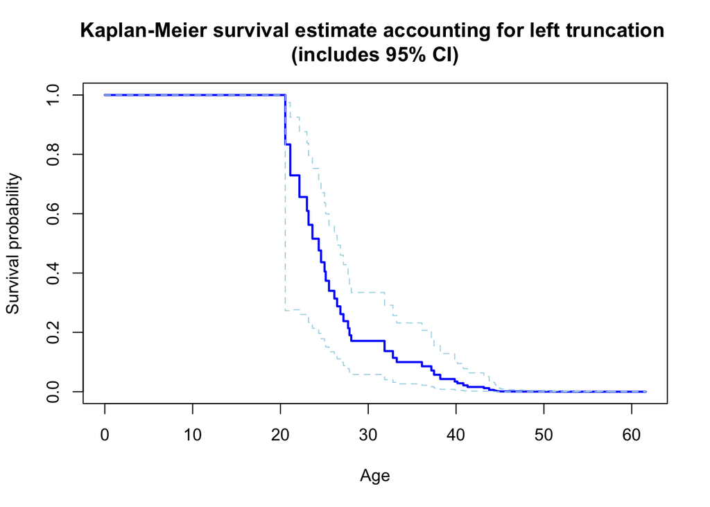

**Figure 2. Kaplan Meier survival curve showing age at blindness due to diabetic retinopathy in untreated eyes without accounting for delayed entry.** The median age at blindness is 44.5 (95% CI: 40.8-48.2).

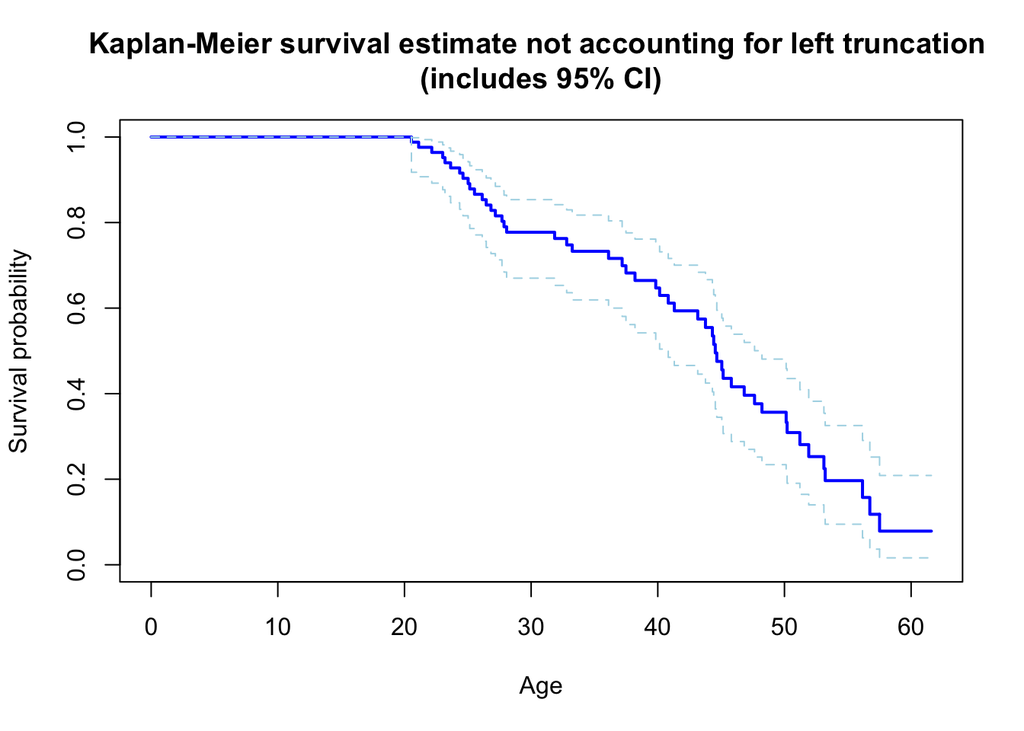